# Problem Set 5

Thalia Felice

2023-02-15

## Question 1

```r
library(tidyverse)
country <- read_delim("gapminder.csv.bz2")
```

*Load data. How many rows/columns do we have?* *Print a small sample of data. Does it look OK?*

```r
nrow(country) %>%
  cat(., "rows")
```

```
## 13055 rows
```

```r
ncol(country) %>%
  cat(., "columns")
```

```
## 25 columns
```

```r
head(country, 5)
```

```
## # A tibble: 5 × 25
##   iso3  name  iso2  region sub-r…¹ inter…²  time total…³ ferti…⁴ lifeE…⁵ child…⁶
##   <chr> <chr> <chr> <chr>  <chr>   <chr>   <dbl>   <dbl>   <dbl>   <dbl>   <dbl>
## 1 ABW   Aruba AW    Ameri… Latin … Caribb…  1960   54211    4.82    65.7      NA
## 2 ABW   Aruba AW    Ameri… Latin … Caribb…  1961   55438    4.66    66.1      NA
## 3 ABW   Aruba AW    Ameri… Latin … Caribb…  1962   56225    4.47    66.4      NA
## 4 ABW   Aruba AW    Ameri… Latin … Caribb…  1963   56695    4.27    66.8      NA
## 5 ABW   Aruba AW    Ameri… Latin … Caribb…  1964   57032    4.06    67.1      NA
## # … with 14 more variables: youthFemaleLiteracy <dbl>, youthMaleLiteracy <dbl>,
## #   adultLiteracy <dbl>, GDP_PC <dbl>, accessElectricity <dbl>,
## #   agriculturalLand <dbl>, agricultureTractors <dbl>, cerealProduction <dbl>,
## #   fertilizerHa <dbl>, co2 <dbl>, greenhouseGases <dbl>, co2_PC <dbl>,
## #   pm2.5_35 <dbl>, battleDeaths <dbl>, and abbreviated variable names
## #   ¹`sub-region`, ²`intermediate-region`, ³totalPopulation, ⁴fertilityRate,
## #   ⁵lifeExpectancy, ⁶childMortality
```

```r
tail(country, 5)
```

```
## # A tibble: 5 × 25
##   iso3  name  iso2  region sub-r…¹ inter…²  time total…³ ferti…⁴ lifeE…⁵ child…⁶
##   <chr> <chr> <chr> <chr>  <chr>   <chr>   <dbl>   <dbl>   <dbl>   <dbl>   <dbl>
## 1 ZWE   Zimb… ZW    Africa Sub-Sa… Easter…  2015  1.38e7    3.90    59.5    62
## 2 ZWE   Zimb… ZW    Africa Sub-Sa… Easter…  2016  1.40e7    3.80    60.3    59.5
## 3 ZWE   Zimb… ZW    Africa Sub-Sa… Easter…  2017  1.42e7    3.71    60.8    58.2
## 4 ZWE   Zimb… ZW    Africa Sub-Sa… Easter…  2018  1.44e7    3.62    61.2    55.9
## 5 ZWE   Zimb… ZW    Africa Sub-Sa… Easter…  2019  1.46e7    3.53    61.5    54.6
## # … with 14 more variables: youthFemaleLiteracy <dbl>, youthMaleLiteracy <dbl>,
## #   adultLiteracy <dbl>, GDP_PC <dbl>, accessElectricity <dbl>,
## #   agriculturalLand <dbl>, agricultureTractors <dbl>, cerealProduction <dbl>,
## #   fertilizerHa <dbl>, co2 <dbl>, greenhouseGases <dbl>, co2_PC <dbl>,
## #   pm2.5_35 <dbl>, battleDeaths <dbl>, and abbreviated variable names
## #   ¹`sub-region`, ²`intermediate-region`, ³totalPopulation, ⁴fertilityRate,
## #   ⁵lifeExpectancy, ⁶childMortality
```

## Question 2

*How many countries are there in the dataset? Analyze all three: iso3, iso2 and name.*

```r
n_distinct(country$name) %>%
  cat(., "distinct countries in names")
```

```
## 250 distinct countries in names
```

```r
n_distinct(country$iso3) %>%
  cat(., "distinct countries in iso3")
```

```
## 253 distinct countries in iso3
```

```r
n_distinct(country$iso2) %>%
  cat(., "distinct countries in iso2")
```

```
## 249 distinct countries in iso2
```

*Find how many names are there for each iso-2 code. Are there any iso-2 codes that correspond to more than one name? What are these countries?*

```r
country %>%
  group_by(iso2) %>%
  distinct(name) %>%
  count() %>%
  filter(n != 1)
```

```
## # A tibble: 1 × 2
## # Groups:   iso2 [1]
##   iso2      n
##   <chr> <int>
## 1 <NA>      2
```

The iso-2 code “NA” is listed for 2 different names. This could account for some of the disparity.

```r
country %>%
  group_by(iso2, name) %>%
  filter(is.na(iso2)) %>%
  select(iso2, iso3, name) %>%
  summarize()
```

```
## # A tibble: 2 × 2
## # Groups:   iso2 [1]
##   iso2  name
##   <chr> <chr>
## 1 <NA>  Namibia
## 2 <NA>  <NA>
```

There is one case where Namibia does not have an iso2 code (and is listed as NA), and a case where the name is NA and the iso2 code is NA.

*Now repeat the same for name and iso3-code. Are there country names that have more than one iso3-code? What are these countries? Hint: two of these entitites are CHANISL and NLD CURACAO.*

```r
country %>%
  group_by(iso3, name) %>%
  filter(is.na(name)) %>%
  select(name) %>%
  count()
```

```
## # A tibble: 4 × 3
## # Groups:   iso3, name [4]
##   iso3        name      n
##   <chr>       <chr> <int>
## 1 CHANISL     <NA>     60
## 2 GBM         <NA>     60
## 3 KOS         <NA>     60
## 4 NLD_CURACAO <NA>     60
```

There are 4 nations with iso3 codes which correspond to the name NA because the name doesn’t exist. These are iso3 code CHANSIL, GBM, KOS and NLD_CURACAO

```r
country %>%
  group_by(name) %>%
  count(iso3)
```

```
## # A tibble: 253 × 3
## # Groups:   name [250]
##    name                iso3      n
##    <chr>               <chr> <int>
##  1 Afghanistan         AFG      60
##  2 Albania             ALB      60
##  3 Algeria             DZA      60
##  4 American Samoa      ASM      60
##  5 Andorra             AND      60
##  6 Angola              AGO      60
##  7 Anguilla            AIA       1
##  8 Antarctica          ATA       1
##  9 Antigua and Barbuda ATG      60
## 10 Argentina           ARG      60
## # … with 243 more rows
```

```r
country %>%
  group_by(iso3) %>%
  count()
```

```
## # A tibble: 253 × 2
## # Groups:   iso3 [253]
##    iso3      n
##    <chr> <int>
##  1 ABW      60
##  2 AFG      60
##  3 AGO      60
##  4 AIA       1
##  5 ALA       1
##  6 ALB      60
##  7 AND      60
##  8 ARE      60
##  9 ARG      60
## 10 ARM      60
## # … with 243 more rows
```

```r
country %>%
  filter(is.na(iso3))
```

```
## # A tibble: 0 × 25
## # … with 25 variables: iso3 <chr>, name <chr>, iso2 <chr>, region <chr>,
## #   sub-region <chr>, intermediate-region <chr>, time <dbl>,
## #   totalPopulation <dbl>, fertilityRate <dbl>, lifeExpectancy <dbl>,
## #   childMortality <dbl>, youthFemaleLiteracy <dbl>, youthMaleLiteracy <dbl>,
## #   adultLiteracy <dbl>, GDP_PC <dbl>, accessElectricity <dbl>,
## #   agriculturalLand <dbl>, agricultureTractors <dbl>, cerealProduction <dbl>,
## #   fertilizerHa <dbl>, co2 <dbl>, greenhouseGases <dbl>, co2_PC <dbl>, …
```

However, there is no nation by name that has multiple associated iso3 codes. This tracks at iso3 is never = NA.

*What is the minimum and maximum year in these data?*

```r
min <- min(country$time, na.rm = TRUE)
```

The minimum year in the dataset is 1960

```r
max <- max(country$time, na.rm = TRUE)
```

The maximum year in the dataset is 2019

## Question 3

*How many missing co2 emissions are there for each year? Analyze both missing CO2 and co2_PC. Which years have most missing data?*

```r
country %>%
  group_by(time) %>%
  filter(is.na(co2),is.na(co2_PC)) %>%
  count() %>%
  arrange(desc(n))
```

```
## # A tibble: 61 × 2
## # Groups:   time [61]
##     time     n
##    <dbl> <int>
##  1  2017   217
##  2  2018   217
##  3  2019   217
##  4  1960    60
##  5  1961    60
##  6  1962    58
##  7  1963    57
##  8  1964    51
##  9  1965    51
## 10  1966    51
## # … with 51 more rows
```

In 2017, 2018 and 2019 there were **217 instances** of missing data for each of these years.

*Make a plot of total CO2 emissions over time for the U.S, China, and India. Add a few more countries of your choice. Explain what do you see.*

```r
country$totalco2 <- country$co2 + country$co2_PC
target3 <- c("United States of America", "China", "India")
```

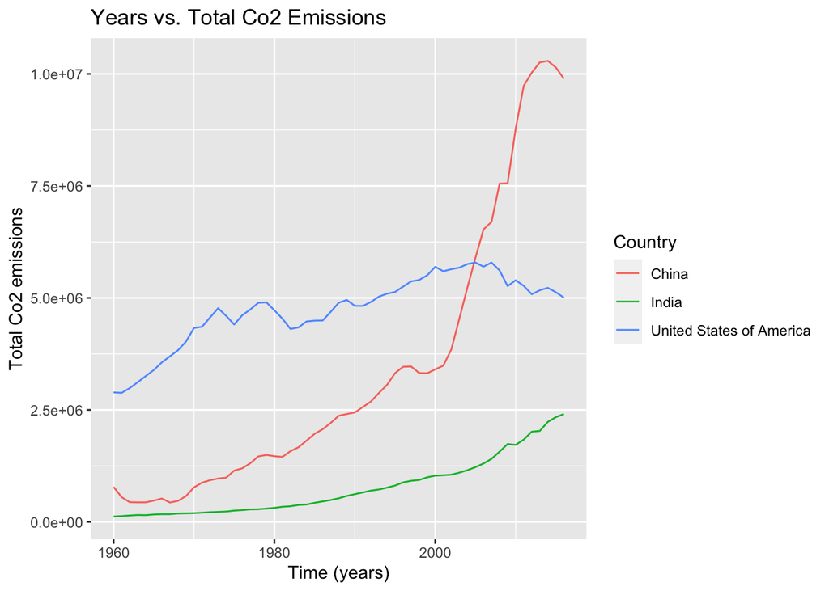

```r
country %>%
  filter(!is.na(totalco2)) %>%
  group_by(name) %>%
  filter(name %in% target3) %>%
  ggplot(aes(time, totalco2, col=factor(name)))+
  geom_line()+
  labs(x="Time (years)", y="Total Co2 emissions", col = "Country", title="Years vs. Total Co2 Emissions")
```

The graph show that overtime for all countries, co2 emissions have increased for all countries. China’s growth has been the most exponential. India’s growth has also been increasing exponentially but at a slower rate. The U.S’s growth is less consistent in its pattern but it’s also generally been increasing. However in recent years the graph shows a decrease, but this could be due in part to the years of missing data.

*Now let’s analyze the CO2 emissions per capita (co2_PC). Make a similar plot of the same countries. What does this figure suggest?*

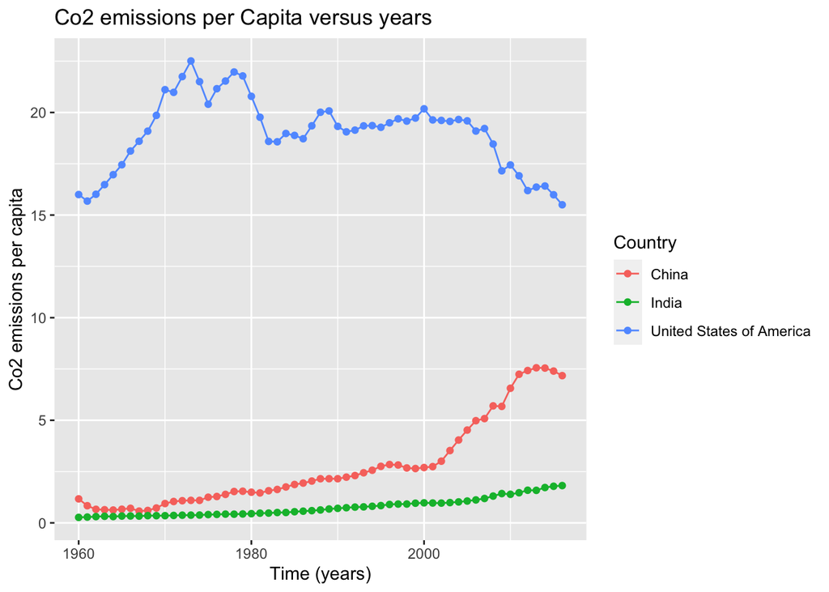

```r
country %>%
  filter(!is.na(co2_PC)) %>%
  group_by(name) %>%
  filter(name %in% target3) %>%
  ggplot(aes(time, co2_PC, col=factor(name)))+
  geom_line()+
  geom_point()+
  labs(x="Time (years)", y="Co2 emissions per capita", col = "Country", title = "Co2 emissions per Capita versus years")
```

Per capita, the **United States** is far and above all other countries in emissions per capita. That said, China has increased drastically in the last decade. India’s increase has been more gradual.

*Compute average CO2 emissions per capita across the continents (assume region is the same as continent). Comment what do you see. Note: just compute averages over countries and ignore the fact that countries are of different size. Hint: Americas 2016 should be 4.80.*

```r
avg_Co2_region <- country %>%
  filter(!is.na(co2_PC), !is.na(region), !is.na(time)) %>%
  group_by(region, time) %>%
  summarize(avg_Co2_PC = mean(co2_PC))
avg_Co2_region
```

```
## # A tibble: 285 × 3
## # Groups:   region [5]
##    region  time avg_Co2_PC
##    <chr>  <dbl>      <dbl>
##  1 Africa  1960      0.291
##  2 Africa  1961      0.300
##  3 Africa  1962      0.299
##  4 Africa  1963      0.310
##  5 Africa  1964      0.349
##  6 Africa  1965      0.385
##  7 Africa  1966      0.422
##  8 Africa  1967      0.607
##  9 Africa  1968      0.781
## 10 Africa  1969      0.824
## # … with 275 more rows
```

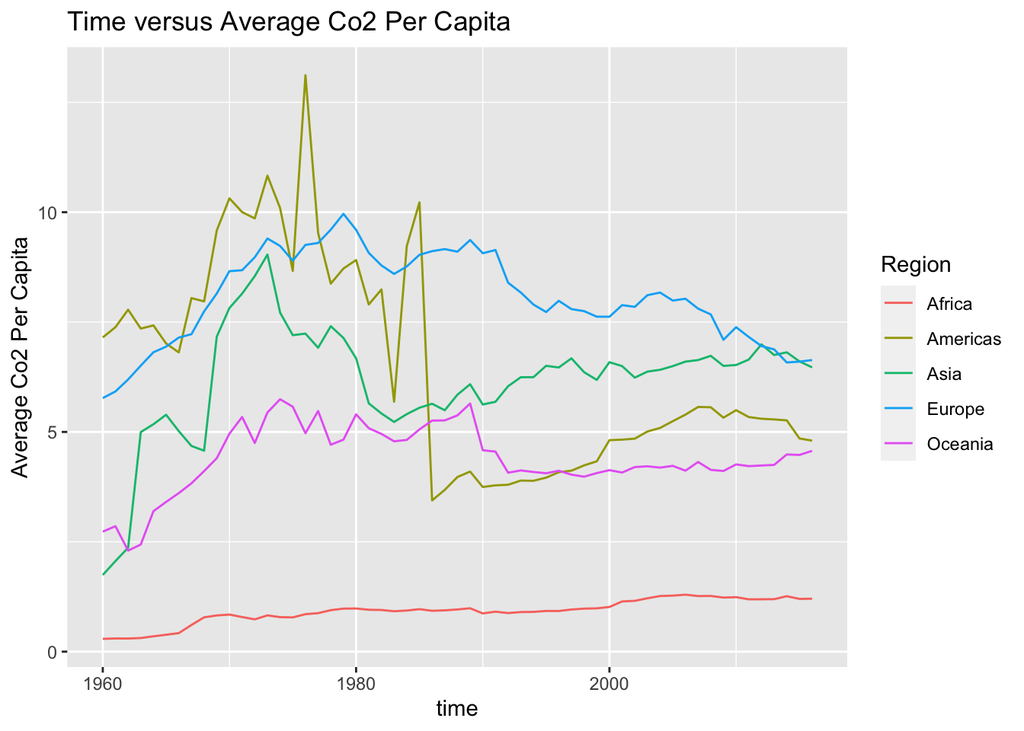

```r
ggplot(data = avg_Co2_region, mapping = aes(x = time, y =avg_Co2_PC, col=factor(region), !is.na(avg_Co2_PC),!is.na(time))) +
  geom_line()+
  labs(y="Average Co2 Per Capita", title ="Time versus Average Co2 Per Capita", col = "Region")
```

*Make a barplot where you show the previous results–average CO2 emissions per capita across continents in 1960 and 2016. Hint: PDF has an exmample of what graph should look like*

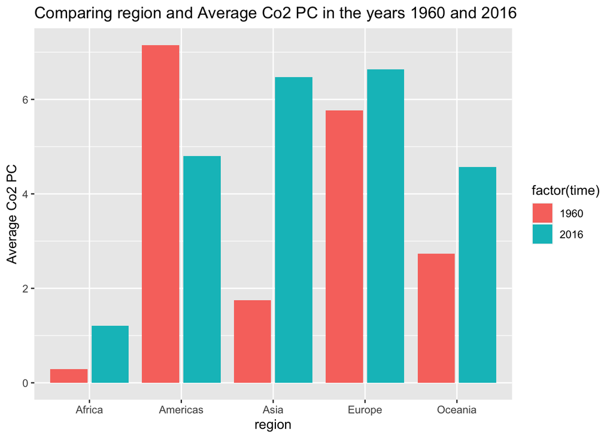

```r
years <- c(1960, 2016)
country %>%
  filter(!is.na(co2_PC), !is.na(region), !is.na(time), time %in% years) %>%
  group_by(region, time) %>%
  summarize(avg_Co2_PC = mean(co2_PC)) %>%
  ggplot()+
  geom_col(aes(x = region, y = avg_Co2_PC, fill = factor(time)), position = "dodge2")+
  labs(y="Average Co2 PC", title = "Comparing region and Average Co2 PC in the years 1960 and 2016", color="Time")
```

*Which countries are the three largest, and three smallest CO2 emitters (in terms of CO2 per capita) in 2019 for each continent? (Assume region is continent).*

```r
country %>%
  filter(time == 2019) %>%
  group_by(region, name) %>%
  summarize(total = sum(totalco2,na.rm=TRUE)) %>%
  arrange(desc(total))
```

```
## # A tibble: 214 × 3
## # Groups:   region [6]
##    region name                     total
##    <chr>  <chr>                    <dbl>
##  1 Africa Algeria                      0
##  2 Africa Angola                       0
##  3 Africa Benin                        0
##  4 Africa Botswana                     0
##  5 Africa Burkina Faso                 0
##  6 Africa Burundi                      0
##  7 Africa Cabo Verde                   0
##  8 Africa Cameroon                     0
##  9 Africa Central African Republic     0
## 10 Africa Chad                         0
## # … with 204 more rows
```

This is a bit of a trick question as all values for 2019 are NA. This makes sense as the most missing data was in the years 207, 2018 and 2019. So there is not enough information to determine who the top emitters per country and per region are for that year.

## Question 4

*Make a scatterplot of GDP per capita versus life expectancy by country, using data for 1960. Make the point size dependent on the country size, and color those according to the continent. Feel free to adjust the plot in other ways to make it better.Comment what do you see there.*

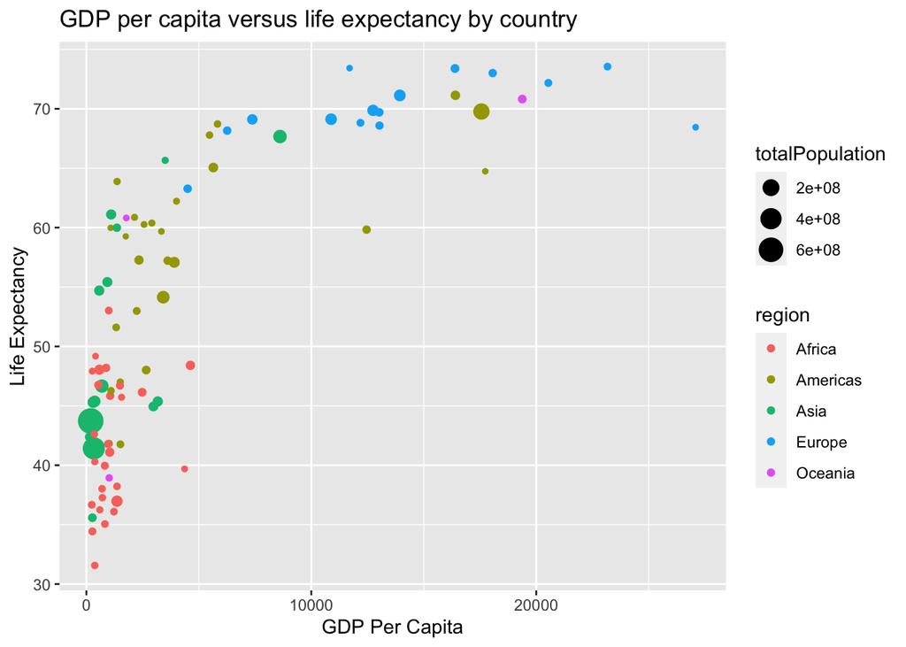

```r
country %>%
  filter(time == 1960, !is.na(name), !is.na(region), !is.na(GDP_PC), !is.na(lifeExpectancy)) %>%
  group_by(name, region) %>%
  ggplot(aes(x= GDP_PC, y=lifeExpectancy, col=region))+
  geom_point(aes(size=totalPopulation))+
  labs(title="GDP per capita versus life expectancy by country", x= "GDP Per Capita", y="Life Expectancy")
```

The graph shows that European nations have both the highest GDP and life expectancy, but European nations are the smallest in population. There doesn’t seem to be a big correlation between life expectancy + GDP and population size, otherwise the largest dots would be clustered at the top or the bottom of the data.

*Make a similar plot, but this time use 2019 data only.*

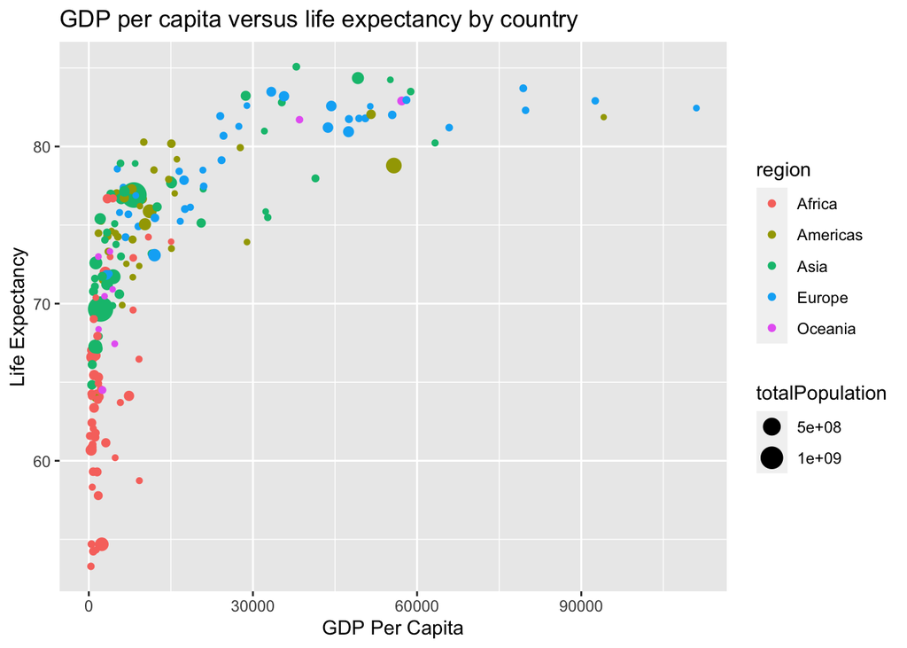

```r
country %>%
  filter(time == 2019, !is.na(name), !is.na(region), !is.na(GDP_PC), !is.na(lifeExpectancy)) %>%
  group_by(name, region) %>%
  ggplot(aes(x= GDP_PC, y=lifeExpectancy, col=region))+
  geom_point(aes(size=totalPopulation))+
  labs(title="GDP per capita versus life expectancy by country", x= "GDP Per Capita", y="Life Expectancy")
```

In this case, Asian nations have cot up with European nations in life expectancy, and are beginning to in terms of GDP per capita. African nations are clustered towards the lower end of both the GDP scale and life expectancy. Europe looks mostly unchanged, and the Americas seem to have moved up a bit generally in GDP.

*Compare these two plots and comment what do you see. How has world developed through the last 60 years?*

In general in the last 60 years the economy has accelerate in much of the world and the global supply change and global economies have become so innately intertwined. In general, by the data, it seems that countries that were ahead in GDP in 1960 are still ahead in 2019. But life expectancy seems to have topped out.

*Compute the average life expectancy for each continent in 1960 and 2019. Do the results fit with what do you see on the figures? Note: here as average I mean just average over countries, ignore the fact that countries are of different size.*

```r
country %>%
  group_by(region) %>%
  filter(time == 1960) %>%
  summarize(avg_le_region = mean(lifeExpectancy, na.rm=TRUE)) %>%
  arrange(rank(desc(avg_le_region)))
```

```
## # A tibble: 6 × 2
##   region   avg_le_region
##   <chr>            <dbl>
## 1 <NA>              70.7
## 2 Europe            68.3
## 3 Americas          58.6
## 4 Oceania           56.4
## 5 Asia              51.6
## 6 Africa            41.5
```

Yes, this does match up with the graphs. Without including the NA, Europe still has the highest average life expectancy and Africa still has the lowest life expectancy! So everything looks good so far.

*Compute the average LE growth from 1960-2019 across the continents. Show the results in the order of growth. Explain what do you see. Hint: Hint: these data (data in long form) is not the simplest to compute growth. But you may want to check out the lag() function. And do not forget to group data by continent when using lag(), otherwise your results will be messed up!*

```r
country %>%
  group_by(region) %>%
  summarize(growth = mean(lifeExpectancy/time, na.rm = TRUE)) %>%
  arrange(desc(growth))
```

```
## # A tibble: 6 × 2
##   region   growth
##   <chr>     <dbl>
## 1 Europe   0.0370
## 2 <NA>     0.0369
## 3 Americas 0.0345
## 4 Oceania  0.0333
## 5 Asia     0.0326
## 6 Africa   0.0265
```

*Show the histogram of GDP per capita for years of 1960 and 2019. Try to put both histograms on the same graph, see how well you can do it!*

[figure not shown]

```r
country %>%
  filter(!is.na(GDP_PC), !is.na(region), !is.na(time), time %in% years) %>%
  group_by(region, time, GDP_PC) %>%
  ggplot()+
  geom_histogram(aes(GDP_PC, fill = factor(time)), position = "dodge2")+
  labs(x="" , y= "GDP Per capita", title = "GDP Per Capita in 1960 and 2019")
```

*What was the ranking of US in terms of life expectancy in 1960 and in 2019? (When counting from top.) Hint: check out the function rank()! Hint2: 17 for 1960.*

```r
country %>%
  filter(!is.na(name), !is.na(lifeExpectancy), !is.na(time), time == 1960)  %>%
  select(lifeExpectancy, name, time) %>%
  mutate(rank = rank(-lifeExpectancy)) %>%
  group_by(name, time) %>%
  arrange(rank)
```

```
## # A tibble: 188 × 4
## # Groups:   name, time [188]
##    lifeExpectancy name                                                time  rank
##             <dbl> <chr>                                              <dbl> <dbl>
##  1           73.5 Norway                                              1960     1
##  2           73.4 Iceland                                             1960     2
##  3           73.4 Netherlands                                         1960     3
##  4           73.0 Sweden                                              1960     4
##  5           72.2 Denmark                                             1960     5
##  6           71.3 Switzerland                                         1960     6
##  7           71.2 New Zealand                                         1960     7
##  8           71.1 Canada                                              1960     8
##  9           71.1 United Kingdom of Great Britain and Northern Irel…  1960     9
## 10           70.8 Australia                                           1960    10
## # … with 178 more rows
```

1960: USA #17

```r
country %>%
  filter(!is.na(name), !is.na(lifeExpectancy), !is.na(time), time == 2019)  %>%
  select(lifeExpectancy, name, time) %>%
  mutate(rank = rank(-lifeExpectancy)) %>%
  group_by(name, time) %>%
  arrange(rank)
```

```
## # A tibble: 196 × 4
## # Groups:   name, time [196]
##    lifeExpectancy name                time  rank
##             <dbl> <chr>              <dbl> <dbl>
##  1           85.1 Hong Kong           2019     1
##  2           84.4 Japan               2019     2
##  3           84.2 Macao               2019     3
##  4           83.7 Switzerland         2019     4
##  5           83.5 Singapore           2019     5
##  6           83.5 Spain               2019     6
##  7           83.2 Korea, Republic of  2019     7
##  8           83.2 Italy               2019     8
##  9           83.0 Liechtenstein       2019     9
## 10           83.0 Sweden              2019    10
## # … with 186 more rows
```

2019: USA #46

*If you did this correctly, then you noticed that US ranking has been falling quite a bit. But we also have more countries in 2019–what about the relative rank divided by the corresponding number of countries that have LE data in the corresponding year? Hint: 0.0904 for 1960.*

```r
rate1960 <- 17/188
rate2019 <-  46/196
```

US for 1960: 0.0904 US for 2019: 0.2347

## How Many Hours were Spent on this Problem Set?

6 Hours